# Introduction to Random Walks in R

Dogukan Nami Oztas

2025-05-16

## What is a Random Walk?

A random walk is a mathematical object, known as a stochastic or random process, that describes a path that consists of a succession of random steps on some mathematical space. In simpler terms, it’s a process where the next position is determined by a random step from the current position.

Random walks are fundamental to understanding more complex models like the Diffusion Decision Model (DDM), where they represent the noisy accumulation of evidence over time leading to a decision.

In this vignette, we’ll explore a simple one-dimensional random walk where evidence accumulates until it reaches one of two decision thresholds.

## Simulating a Single Random Walk Trial

We have created a function simulate_random_walk_trial() in R/01_random_walk_simulator.R to simulate a single instance of this process.

**Key Parameters:**

- start_point: The initial value of the evidence (default: 0).
- threshold: The (positive) value of the decision boundaries. A decision is made when the absolute evidence reaches this threshold (default: 10).
- drift: The average amount added to the evidence at each step. A positive drift biases the walk towards the upper threshold, and a negative drift biases it towards the lower threshold (default: 0.1).
- sd_step: The standard deviation of the step size, representing the noise in the accumulation process (default: 1).
- max_steps: The maximum number of steps allowed before a trial is terminated (to prevent infinite loops if a threshold is never reached) (default: 10000).

Let’s simulate a few single trials:

```r
set.seed(123) # For reproducibility

trial1 <- simulate_random_walk_trial(drift = 0.2, threshold = 5, sd_step = 1)
print(paste("Trial 1: Choice =", trial1$choice, ", RT (steps) =", trial1$rt))
```

```
## [1] "Trial 1: Choice = 1 , RT (steps) = 13"
```

```r
trial2 <- simulate_random_walk_trial(drift = -0.1, threshold = 5, sd_step = 1)
print(paste("Trial 2: Choice =", trial2$choice, ", RT (steps) =", trial2$rt))
```

```
## [1] "Trial 2: Choice = -1 , RT (steps) = 13"
```

```r
trial3 <- simulate_random_walk_trial(drift = 0.01, threshold = 5, sd_step = 1, max_steps = 50) # Forcing a potential non-decision
print(paste("Trial 3: Choice =", trial3$choice, ", RT (steps) =", trial3$rt))
```

```
## [1] "Trial 3: Choice = 1 , RT (steps) = 11"
```

The choice output is 1 for the upper threshold, -1 for the lower threshold, and NA if max_steps was reached. The rt is the number of steps taken.

## Simulating a Random Walk Experiment

To understand the behavior of the random walk model, we typically simulate many trials. The simulate_random_walk_experiment() function handles this. It takes n_trials as an argument and any other parameters that simulate_random_walk_trial() accepts.

Let’s simulate an experiment with 1000 trials:

```r
set.seed(456)
n_sim_trials <- 1000
rw_data <- simulate_random_walk_experiment(
  n_trials = n_sim_trials,
  threshold = 10,
  drift = 0.05, # A slight positive drift
  sd_step = 1.5
)

# Display the first few rows of the simulated data
# Using kable for nicer printing if knitr is rendering to HTML
knitr::kable(head(rw_data), caption = "First 6 trials of the simulated random walk experiment.")
```

First 6 trials of the simulated random walk experiment.

| trial | choice | rt |
| --- | --- | --- |
| 1 | 1 | 19 |
| 2 | 1 | 78 |
| 3 | 1 | 134 |
| 4 | 1 | 54 |
| 5 | 1 | 48 |
| 6 | 1 | 28 |

The resulting rw_data is a data frame containing the trial number, choice, and rt for each simulated trial.

### Analyzing Experiment Results

#### **1. Choice Proportions**

We can calculate the proportion of choices for the upper and lower thresholds.

```r
# Remove NA choices if any (e.g., if max_steps was reached)
valid_choices <- na.omit(rw_data$choice)

choice_counts <- table(valid_choices)
choice_proportions <- prop.table(choice_counts)


knitr::kable(as.data.frame(choice_proportions), col.names = c("Choice", "Proportion"), caption = "Choice Proportions")
```

Choice Proportions

| Choice | Proportion |
| --- | --- |
| -1 | 0.103 |
| 1 | 0.897 |

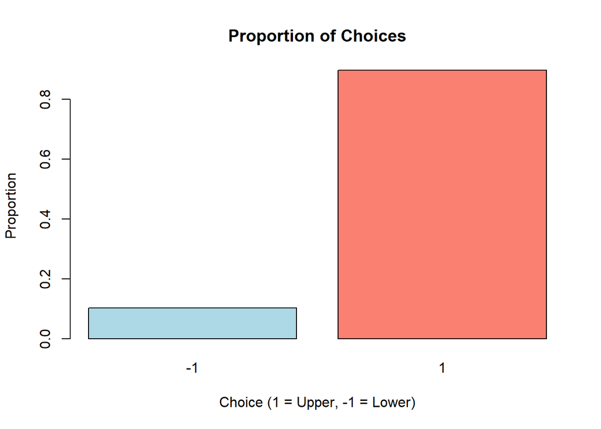

```r
# A simple bar plot of choice proportions
barplot(choice_proportions,
        main = "Proportion of Choices",
        xlab = "Choice (1 = Upper, -1 = Lower)",
        ylab = "Proportion",
        col = c("lightblue", "salmon"))
```

With a positive drift (drift = 0.05), we expect more choices for the upper threshold (Choice 1).

#### **2. Reaction Time (RT) Distributions**

The distribution of reaction times (number of steps) is a key output of these models. We can plot histograms for RTs associated with each choice.

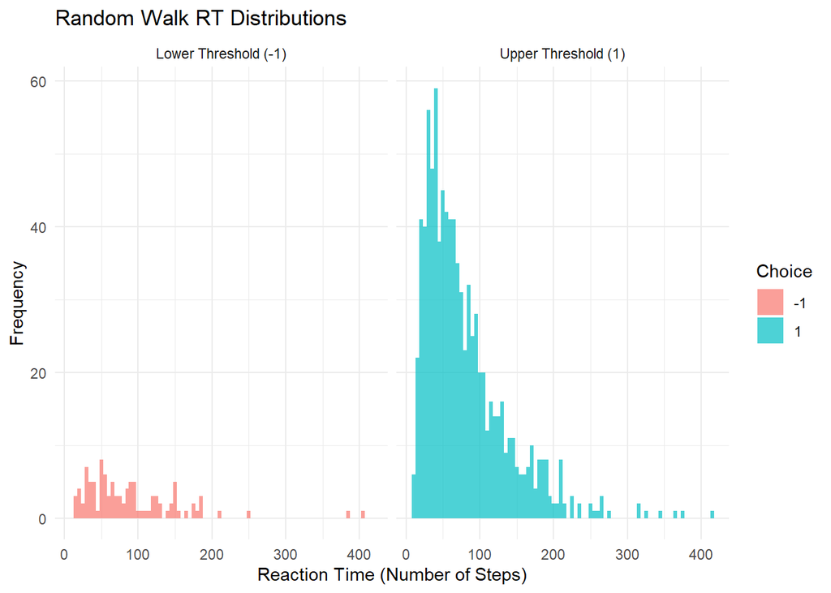

```r
# Filter out NA RTs (if any trial hit max_steps)
valid_rt_data <- subset(rw_data, !is.na(rt))

ggplot(valid_rt_data, aes(x = rt, fill = factor(choice))) +
  geom_histogram(binwidth = 5, alpha = 0.7, position = "identity") +
  facet_wrap(~factor(choice, labels = c("Lower Threshold (-1)", "Upper Threshold (1)"))) +
  labs(
    title = "Random Walk RT Distributions",
    x = "Reaction Time (Number of Steps)",
    y = "Frequency",
    fill = "Choice"
  ) +
  theme_minimal()
```

```r
# Summary statistics for RTs
rt_summary <- valid_rt_data %>%
  group_by(choice) %>%
  summarise(
    Mean_RT = mean(rt),
    Median_RT = median(rt),
    SD_RT = sd(rt),
    Min_RT = min(rt),
    Max_RT = max(rt),
    N = n()
  )

knitr::kable(rt_summary, caption = "Summary Statistics for RTs by Choice")
```

Summary Statistics for RTs by Choice

| choice | Mean_RT | Median_RT | SD_RT | Min_RT | Max_RT | N |
| --- | --- | --- | --- | --- | --- | --- |
| -1 | 89.05825 | 72 | 66.33439 | 13 | 404 | 103 |
| 1 | 78.83946 | 63 | 56.25130 | 9 | 415 | 897 |

**Observations:**

- The RT distributions are typically positively skewed (long tail to the right).
- The average RT can be influenced by the drift rate, threshold, and noise.

## Effect of Parameters

Let’s briefly explore how changing parameters affects the outcome.

### Effect of Drift Rate (drift)

A stronger (absolute) drift rate should lead to faster decisions and a higher probability of choosing the threshold in the direction of the drift.

```r
set.seed(789)
drift_low_data <- simulate_random_walk_experiment(
  n_trials = n_sim_trials, drift = 0.01, threshold = 10, sd_step = 1)
drift_high_data <- simulate_random_walk_experiment(
  n_trials = n_sim_trials, drift = 0.5, threshold = 10, sd_step = 1)

# You would then plot and compare choice proportions and RT distributions for these.
# For example:
# prop.table(table(na.omit(drift_low_data$choice)))
# prop.table(table(na.omit(drift_high_data$choice)))
# hist(drift_low_data$rt[!is.na(drift_low_data$rt) & drift_low_data$choice == 1])
# hist(drift_high_data$rt[!is.na(drift_high_data$rt) & drift_high_data$choice == 1])
```

### Effect of Threshold (threshold)

Higher thresholds generally lead to slower but more accurate (less influenced by noise, more by drift) decisions.

```r
# This chunk is set to eval=FALSE for brevity.
set.seed(101112)
thresh_low_data <- simulate_random_walk_experiment(
  n_trials = n_sim_trials, drift = 0.05, threshold = 5, sd_step = 1)
thresh_high_data <- simulate_random_walk_experiment(
  n_trials = n_sim_trials, drift = 0.05, threshold = 15, sd_step = 1)

# Compare choice proportions and RT distributions.
```

## Conclusion

This vignette demonstrated how to simulate a simple random walk model in R. We saw how to simulate single trials and entire experiments, and how to analyze basic outputs like choice proportions and RT distributions. This forms a conceptual basis for understanding the more complex Diffusion Decision Model, which operates in continuous time.

The next step would be to implement the Diffusion Model itself, which is essentially a continuous-time version of this random walk.